# Compress large files for GitHub

Kyle Gontjes

2026-01-10

Purpose: Not all files are small enough to host on GitHub using standard processes

# Environment

```r
#Packages
packages <- c("tidyverse",'qs','float',"rhdf5")

#Load Packages
invisible(lapply(packages,library,character.only=T,quietly=T))

# Print environment
set.seed(0104)
Sys.info()
```

```
                                                                                            sysname
                                                                                           "Darwin"
                                                                                            release
                                                                                           "25.2.0"
                                                                                            version
"Darwin Kernel Version 25.2.0: Tue Nov 18 21:09:34 PST 2025; root:xnu-12377.61.12~1/RELEASE_X86_64"
                                                                                           nodename
                                                                         "0587669575.vpn.umich.net"
                                                                                            machine
                                                                                           "x86_64"
                                                                                              login
                                                                                             "root"
                                                                                               user
                                                                                         "kgontjes"
                                                                                     effective_user
                                                                                         "kgontjes"
```

# Phylogenetic distance matrix of BL/BLI reconstructions: ./data/empirical/joint_reconstruction/joint_uncertainty_asr_phylo_dist_matrix.RDS

```r
# Phylogenetic distance matrix
joint_uncertainty_asr_phylo_dist_matrix <- readRDS("./data/empirical/joint_reconstruction/joint_uncertainty_asr_phylo_dist_matrix.RDS")

paste0("Class of object (must be dist for this approach to work: ",class(joint_uncertainty_asr_phylo_dist_matrix))
```

```
[1] "Class of object (must be dist for this approach to work: dist"
```

```r
# Get upper triangle of a float conversion of the distance matrix
lower_tri_values <- fl(as.numeric(joint_uncertainty_asr_phylo_dist_matrix))

# Length
L <- length(lower_tri_values)

# Compute chunk size
chunk_size <- ceiling(L / 5)

# Split into 5 chunks
chunks <- list(
  lower_tri_values[1:chunk_size],
  lower_tri_values[(chunk_size + 1):(2*chunk_size)],
  lower_tri_values[(2*chunk_size + 1):(3*chunk_size)],
  lower_tri_values[(3*chunk_size + 1):(4*chunk_size)],
  lower_tri_values[(4*chunk_size + 1):L]  # last chunk may be slightly smaller
)

# Convert each chunk to float32 and save
for (i in 1:5) {
  chunk_f32 <- fl(chunks[[i]])
  qsave(chunk_f32, paste0("./data/empirical/joint_reconstruction/joint_uncertainty_asr_phylo_dist_matrix_lower_triangle_chunk_", i, ".qs"), preset = "high")
}
```

## Reconstruct matrix and determine differences

1. Here, we provide a quick function to reconstruct the distance matrix
2. Notice that there are only small differences between the utilized distance matrix and reconstructed matrix

```r
# Load chunks
lower_tri_1 <- qread("./data/empirical/joint_reconstruction/joint_uncertainty_asr_phylo_dist_matrix_lower_triangle_chunk_1.qs")
lower_tri_2 <- qread("./data/empirical/joint_reconstruction/joint_uncertainty_asr_phylo_dist_matrix_lower_triangle_chunk_2.qs")
lower_tri_3 <- qread("./data/empirical/joint_reconstruction/joint_uncertainty_asr_phylo_dist_matrix_lower_triangle_chunk_3.qs")
lower_tri_4 <- qread("./data/empirical/joint_reconstruction/joint_uncertainty_asr_phylo_dist_matrix_lower_triangle_chunk_4.qs")
lower_tri_5 <- qread("./data/empirical/joint_reconstruction/joint_uncertainty_asr_phylo_dist_matrix_lower_triangle_chunk_5.qs")

# Stitch together the chunks
lower_vals_restitch <- c(lower_tri_1,lower_tri_2,lower_tri_3,lower_tri_4,lower_tri_5)

# Function to reconstruct distance matrix
reconstruct_distance_matrix <- function(lower_vals) {
  # Convert to numeric
  lower_vals <- as.numeric(lower_vals)

  # Get number of observations
  L <- length(lower_vals)
  n <- as.integer((1 + sqrt(1 + 8 * L)) / 2)

  # Create distance object
  distance_obj <- structure(lower_vals, Size = n, class = "dist")

  # Recreate matrix
  recreated_matrix <- as.matrix(distance_obj)

  recreated_matrix
}

# Implementation
rebuilt_matrix <- reconstruct_distance_matrix(lower_vals_restitch)

## These are generally similar. With differences due to floating point rounding errors
paste0("Dimensions of reconstructed matrix: ")
```

```
[1] "Dimensions of reconstructed matrix: "
```

```r
dim(rebuilt_matrix)
```

```
[1] 9400 9400
```

```r
paste0("How many cells are exactly the same?")
```

```
[1] "How many cells are exactly the same?"
```

```r
joint_uncertainty_asr_phylo_dist_matrix_as_matrix <- as.matrix(joint_uncertainty_asr_phylo_dist_matrix)
table(rebuilt_matrix == joint_uncertainty_asr_phylo_dist_matrix_as_matrix)
```

```
   FALSE     TRUE
88345710    14290
```

```r
paste0("Determine differences between matrices: ")
```

```
[1] "Determine differences between matrices: "
```

```r
diff <-  rebuilt_matrix - joint_uncertainty_asr_phylo_dist_matrix_as_matrix
all.equal(rebuilt_matrix, joint_uncertainty_asr_phylo_dist_matrix_as_matrix, tolerance = 1e-8)
```

```
[1] "Mean relative difference: 2.148205e-08"
```

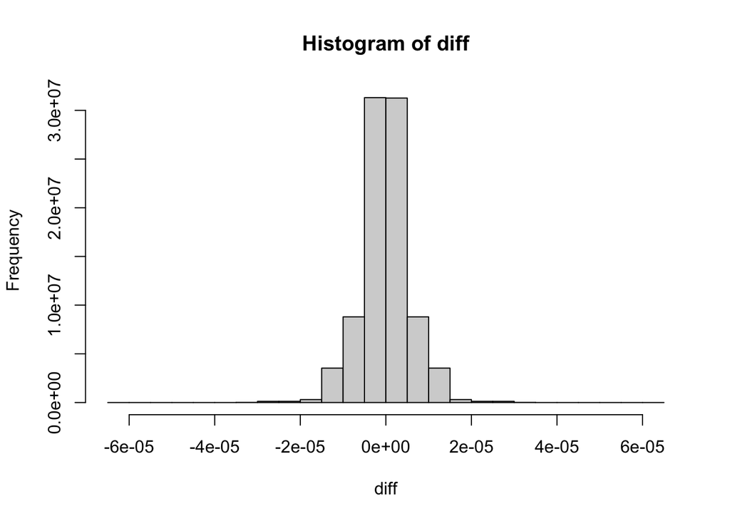

```r
hist(diff)
```

```r
fivenum(diff)
```

```
[1] -6.102729e-05 -2.725857e-06 -3.876330e-10  2.726577e-06  6.093593e-05
```

# Consensus matrix of dbscan assignment across multiple seeds: ./data/empirical/joint_reconstruction/joint_uncertainty_dbscan_multiple_seeds_consensus_matrix.RDS

```r
joint_uncertainty_dbscan_multiple_seeds_consensus_matrix <- readRDS("./data/empirical/joint_reconstruction/joint_uncertainty_dbscan_multiple_seeds_consensus_matrix.RDS")
qsave(joint_uncertainty_dbscan_multiple_seeds_consensus_matrix, "./data/empirical/joint_reconstruction/joint_uncertainty_dbscan_multiple_seeds_consensus_matrix.qs", preset = 'high')
```

# Parent child data frames for each reconstruction: ./data/empirical/phyloAMR/joint_states_parent_child_dfs.RDS

```r
joint_states_parent_child_dfs <- readRDS("./data/empirical/phyloAMR/joint_states_parent_child_dfs.RDS")
qsave(joint_states_parent_child_dfs, "./data/empirical/phyloAMR/joint_states_parent_child_dfs.qs", preset = 'high')
```

# Pairwise genotype data: ./data/empirical/phyloAMR/pairwise_synchronous_transitions_genotype_as_comparitor.RDS

```r
pairwise_synchronous_transitions_genotype_as_comparitor <- readRDS("./data/empirical/phyloAMR/pairwise_synchronous_transitions_genotype_as_comparitor.RDS")
qsave(pairwise_synchronous_transitions_genotype_as_comparitor, "./data/empirical/phyloAMR/pairwise_synchronous_transitions_genotype_as_comparitor.qs", preset = 'high')
```

# Ancestral state reconstruction clustering: ./data/empirical/phyloAMR/phenotype_genotype_joint_uncertainty_asr_clustering.RDS

```r
phenotype_genotype_joint_uncertainty_asr_clustering <- readRDS("./data/empirical/phyloAMR/phenotype_genotype_joint_uncertainty_asr_clustering.RDS")
qsave(phenotype_genotype_joint_uncertainty_asr_clustering, "./data/empirical/phyloAMR/phenotype_genotype_joint_uncertainty_asr_clustering.qs", preset = 'high')
```